# Non-Prioritized Goals in NE Districts

Janette Avelar

2026-02-13

The goal of this analysis is to understand the goals district superintendents did *not* select as needing substantial change, and whether there are similarities across these districts that might help explain their selection patterns. The analysis focuses on questions 4 & 5:

**In order to achieve your district’s long-term goals, how much change is needed in the following areas related to teaching, learning, and student support?**

I’m specifically interested in the response option *no change required*, thus responses are coded to 1 and 0 for any other response (except `NA`).

# Basic descriptives

|  | Goals not being prioritized | Total respondents | % Not prioritizing | SD | Min | Max |
| --- | --- | --- | --- | --- | --- | --- |
| 1 | What teachers teach | 302 | 0.08 | 0.27 | 0 | 1 |
| 2 | How teachers teach | 302 | 0.02 | 0.14 | 0 | 1 |
| 3 | How your district assesses student learning | 303 | 0.1 | 0.3 | 0 | 1 |
| 4 | How your district addresses students' non-academic needs | 303 | 0.13 | 0.33 | 0 | 1 |
| 5 | How the adults in your district treat students | 304 | 0.26 | 0.44 | 0 | 1 |
| 6 | What the adults in your district think students are capable of | 303 | 0.13 | 0.34 | 0 | 1 |
| 7 | What decisions students can make about their learning | 302 | 0.06 | 0.24 | 0 | 1 |
| 8 | How your district places students in courses | 302 | 0.29 | 0.46 | 0 | 1 |
| 9 | How your district supports teachers to improve their practice | 299 | 0.04 | 0.2 | 0 | 1 |
| 10 | How your district supports principals to improve their practice | 299 | 0.1 | 0.3 | 0 | 1 |

[output cut: 5 more lines]

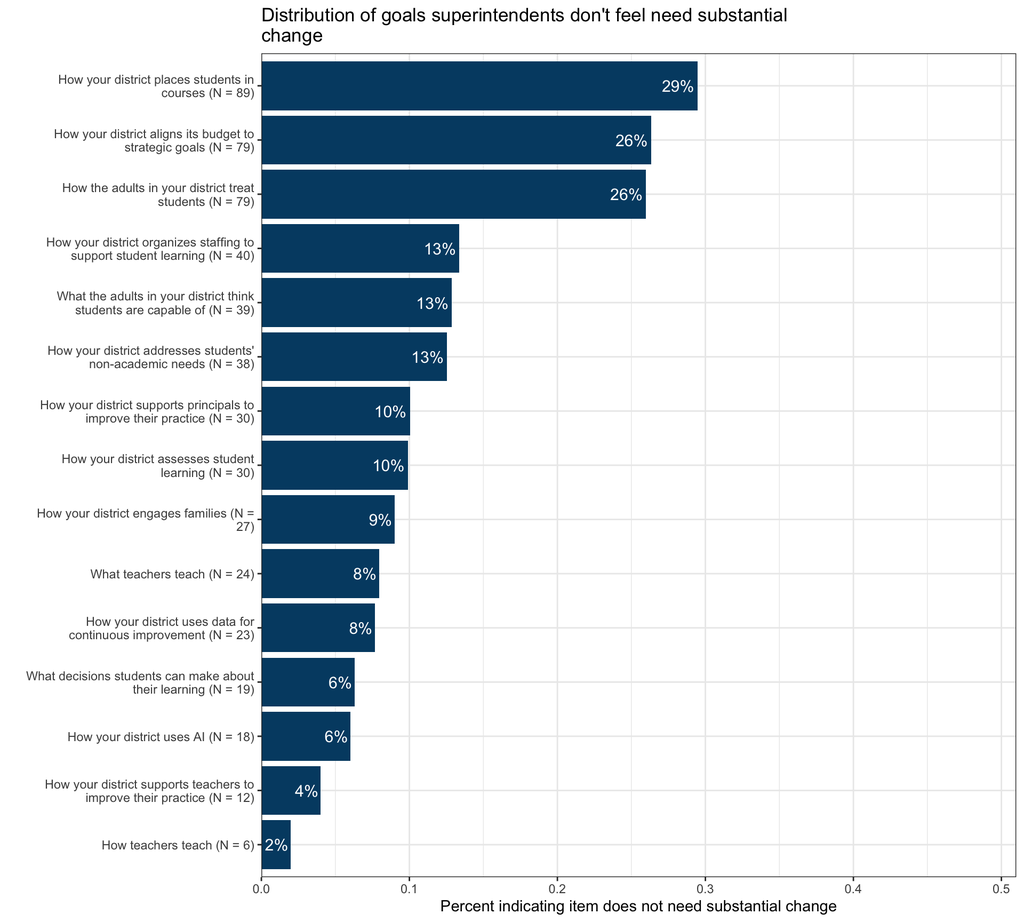

# Stacked bars

## By tenure

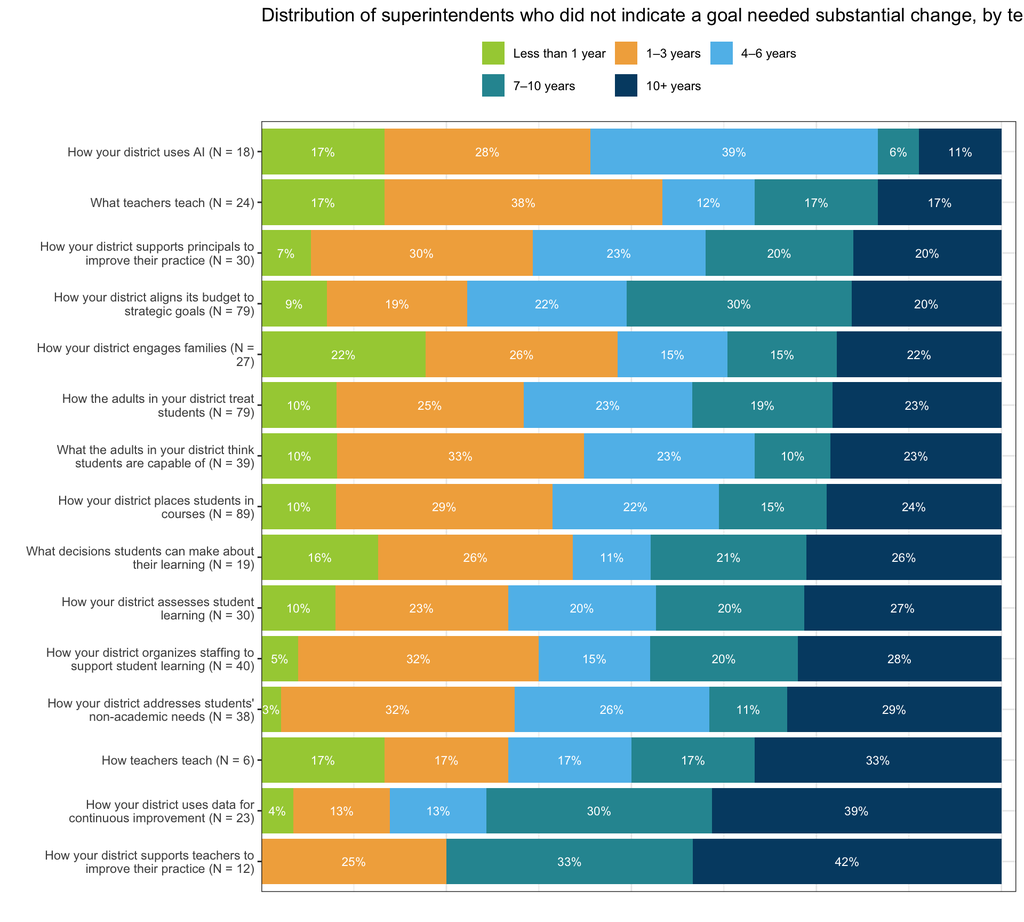

## By goal: Student engagement

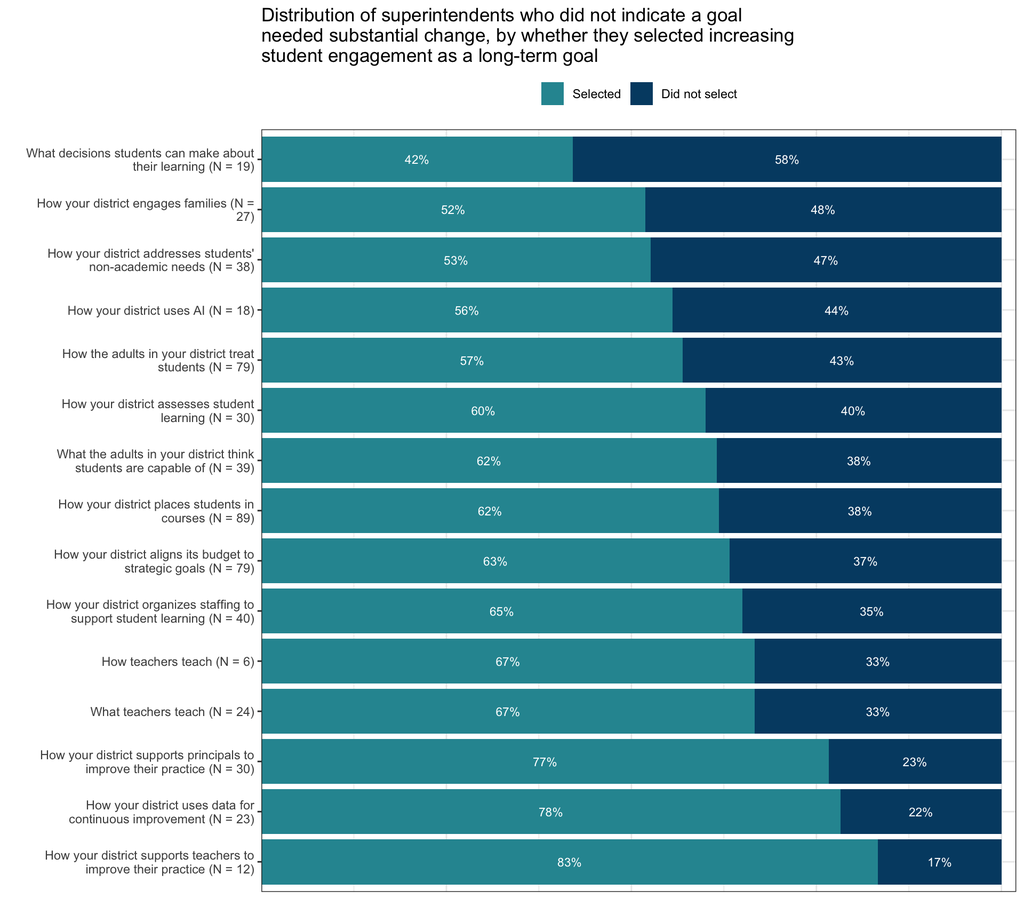

## By goal: Create a safe and welcoming school community

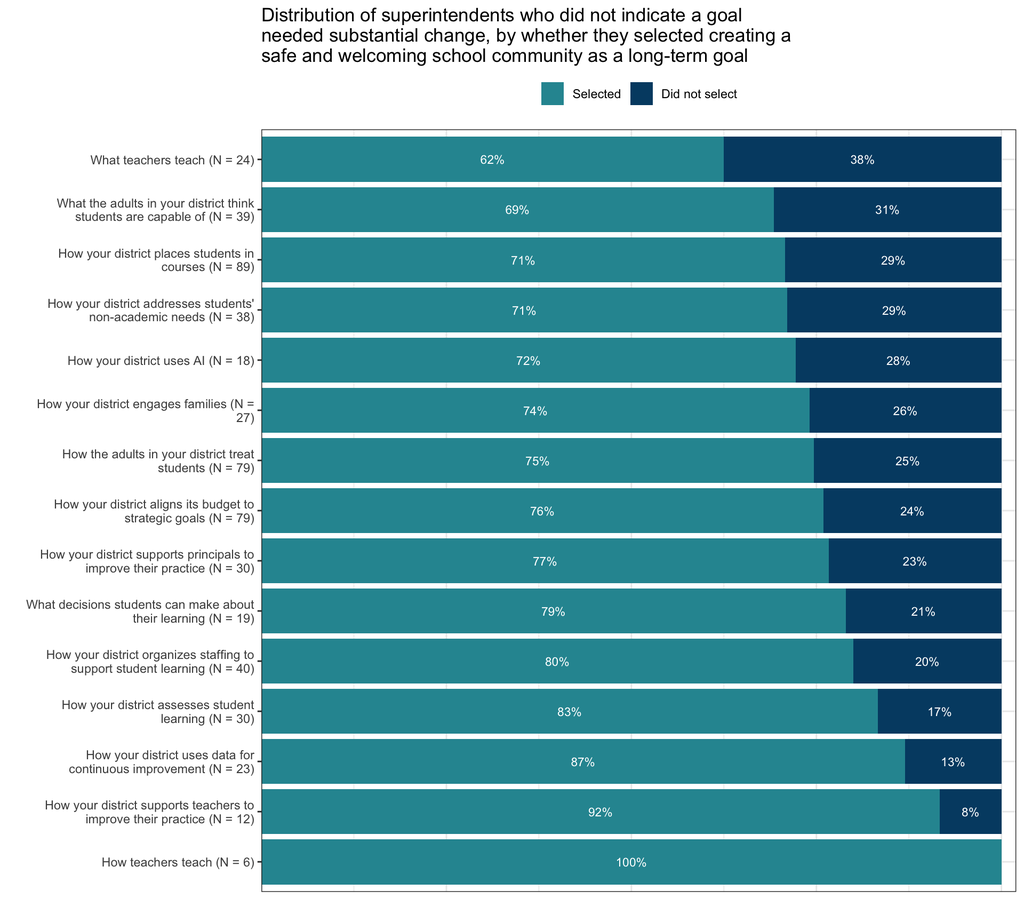

## By goal: Improve academic achievement

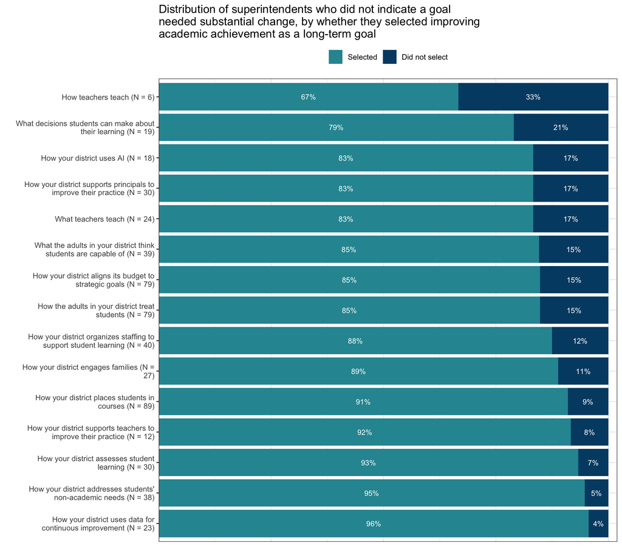

## By goal: Eliminate disparities in outcomes

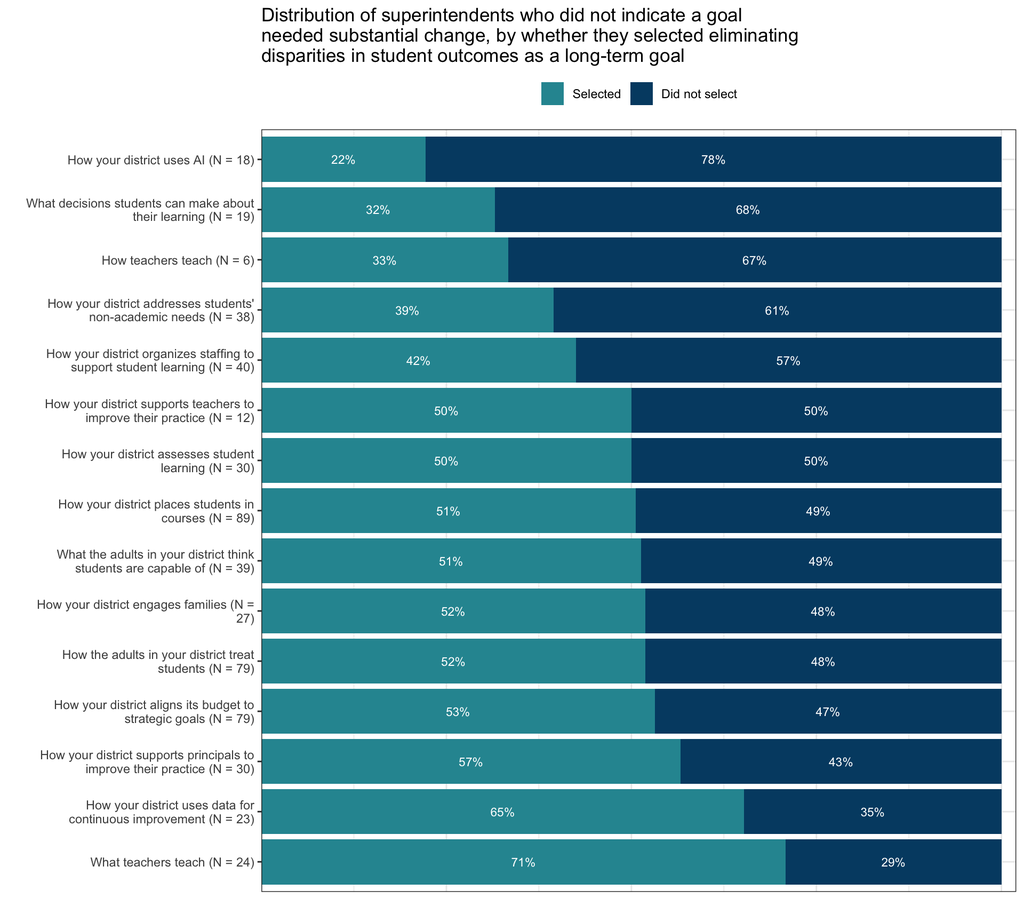

## By goal: Develop students’ durable skills

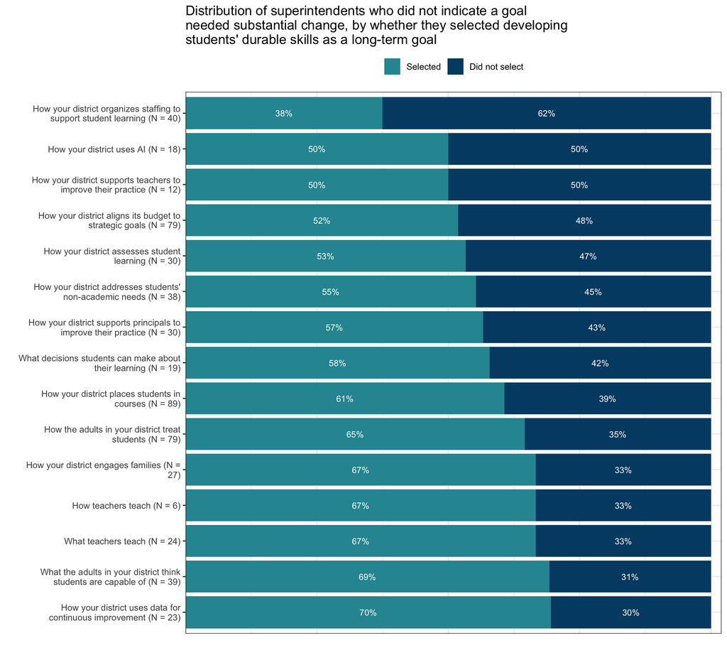

## By goal: Expand access to postsecondary education

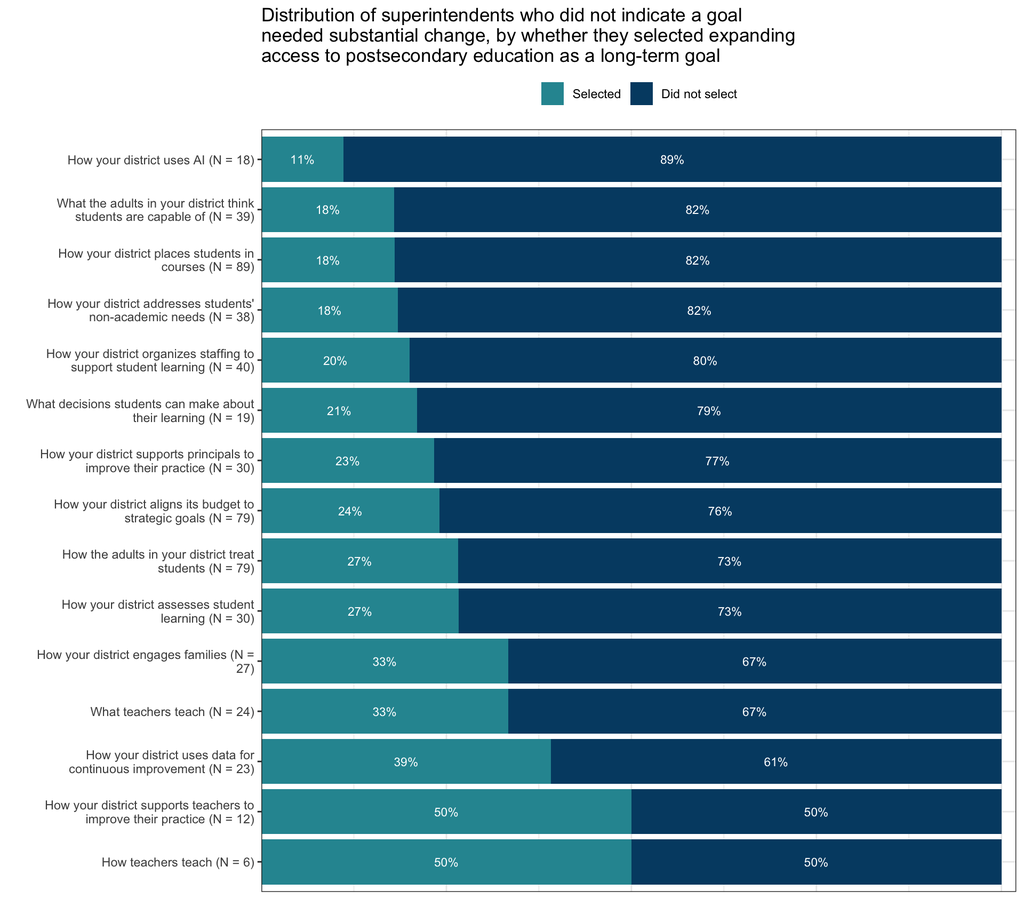

## By goal: Strengthen career preparation

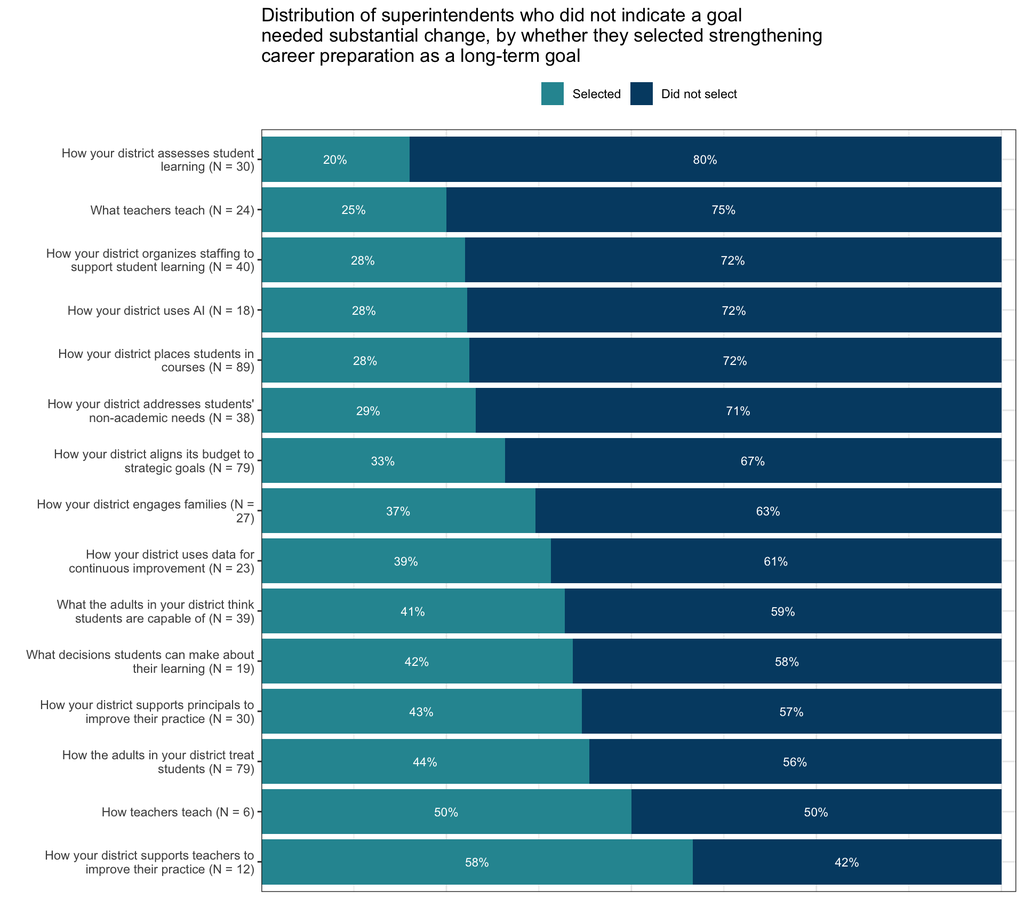

## By goal: Improve instructional quality

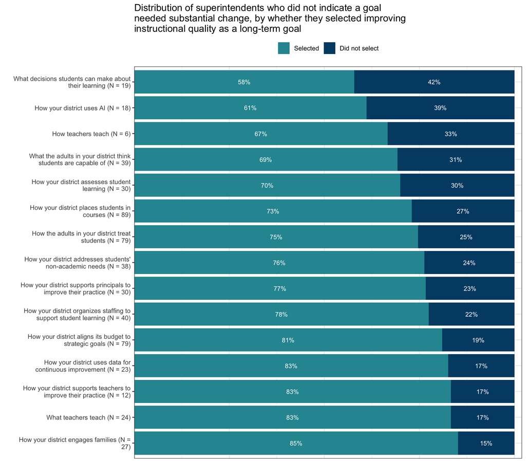

## By belief: I believe my leadership positively influences outcomes for students in my district today.

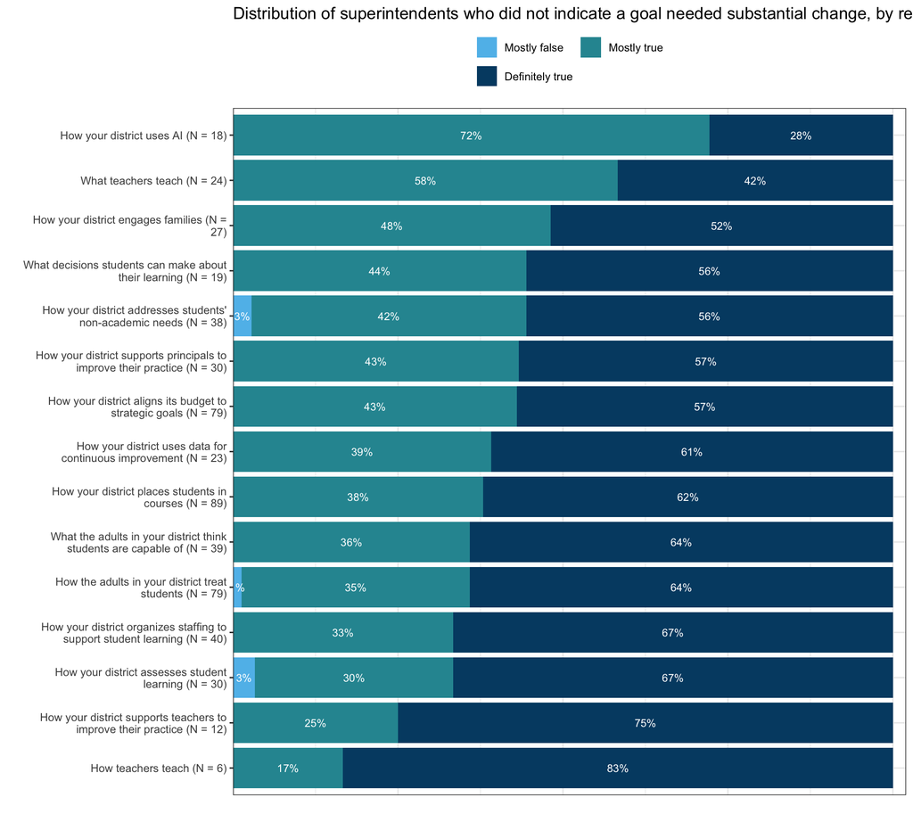

## By belief: I believe my leadership will positively influence outcomes for students in my district even after I retire or move on.

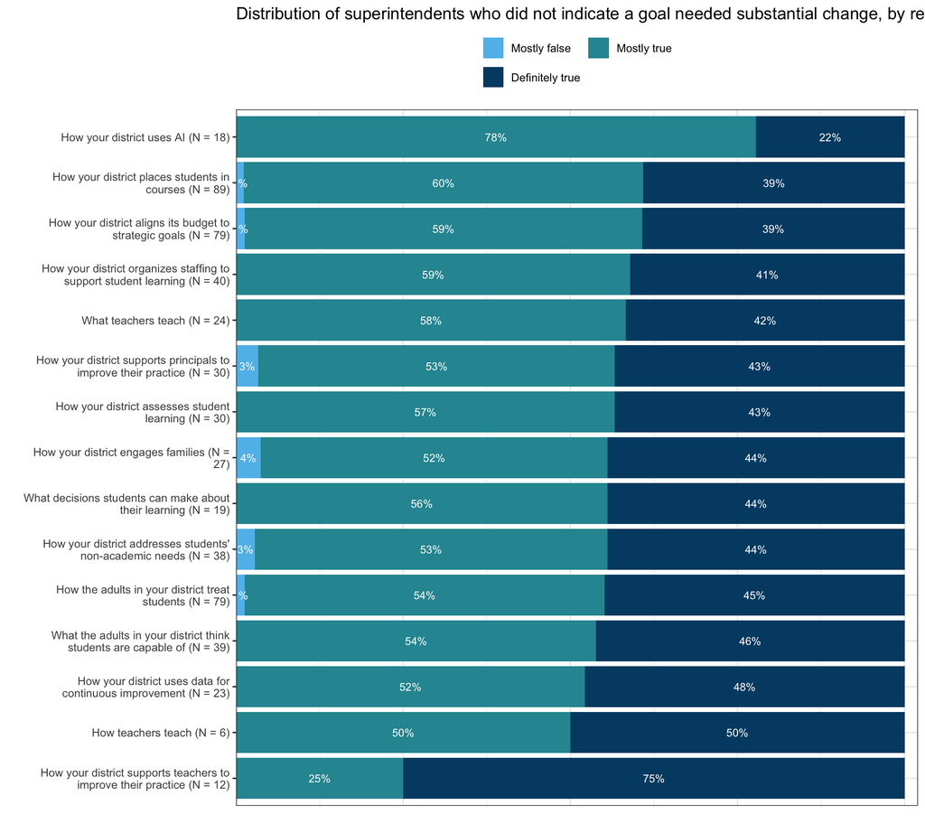

## By belief: Addressing educational inequities is an essential part of my leadership responsibilities.

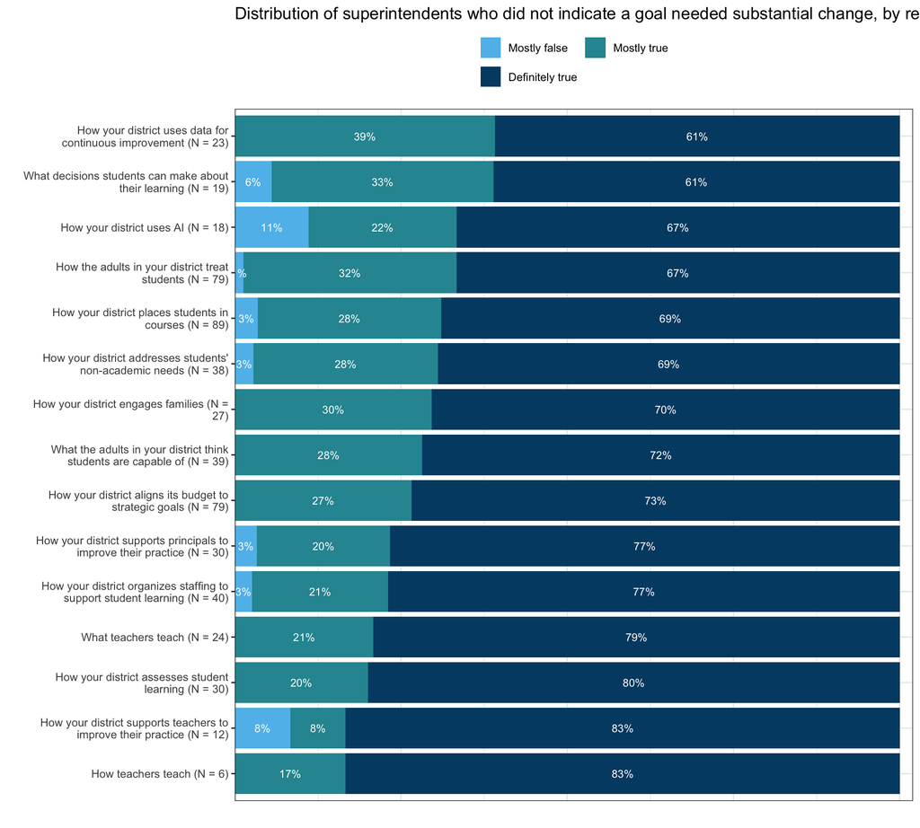

## By belief: I feel enough job security to take strategic risks.

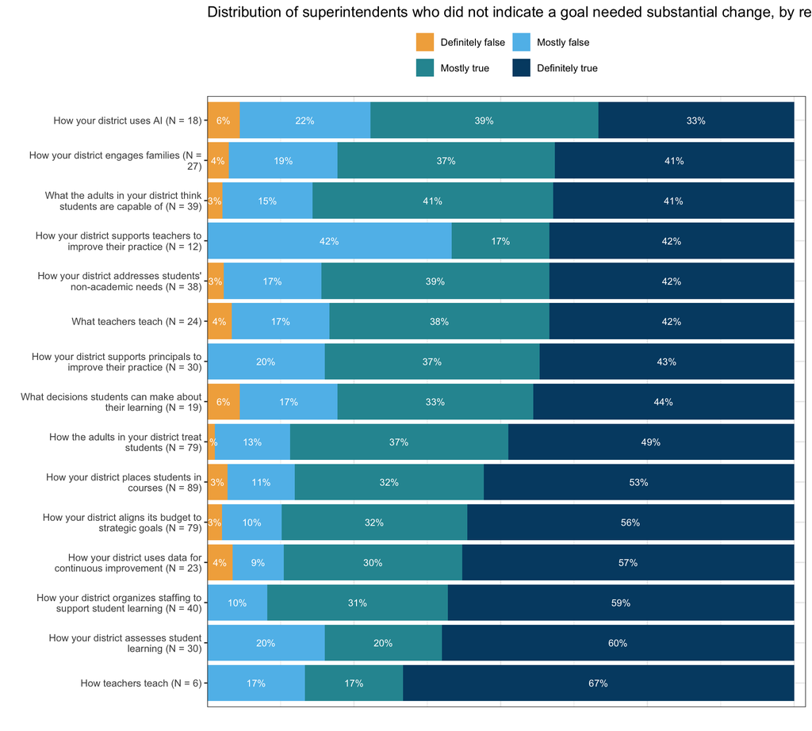

## By belief: I notice a strong desire among district/central office staff to take on new challenges.

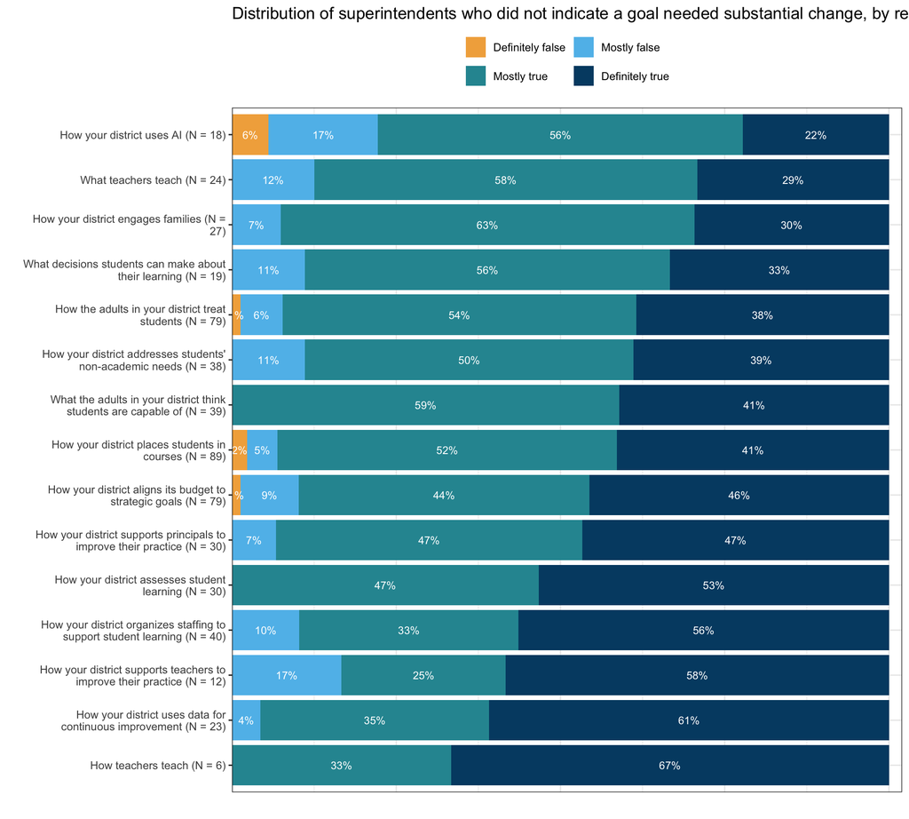

## By belief: I feel strong expectations from stakeholders to lead transformational change in my district.

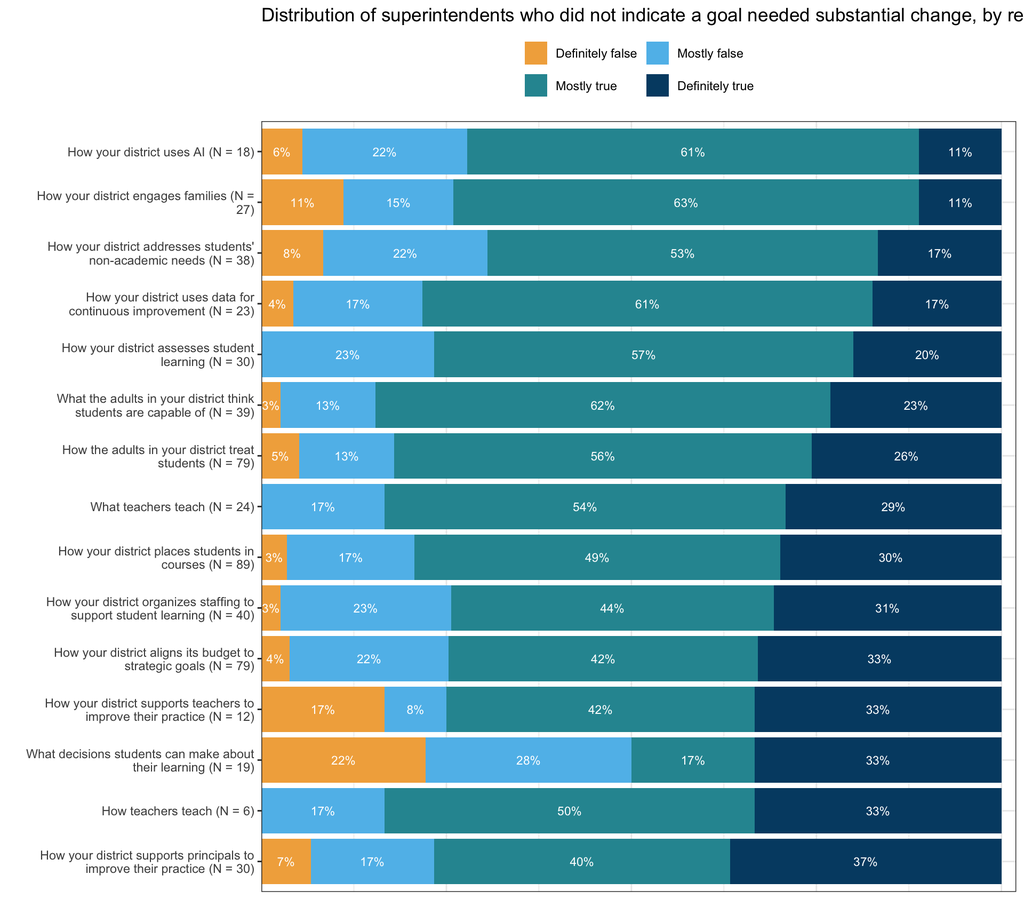

## By belief: I feel personally motivated to lead transformational change in my district.

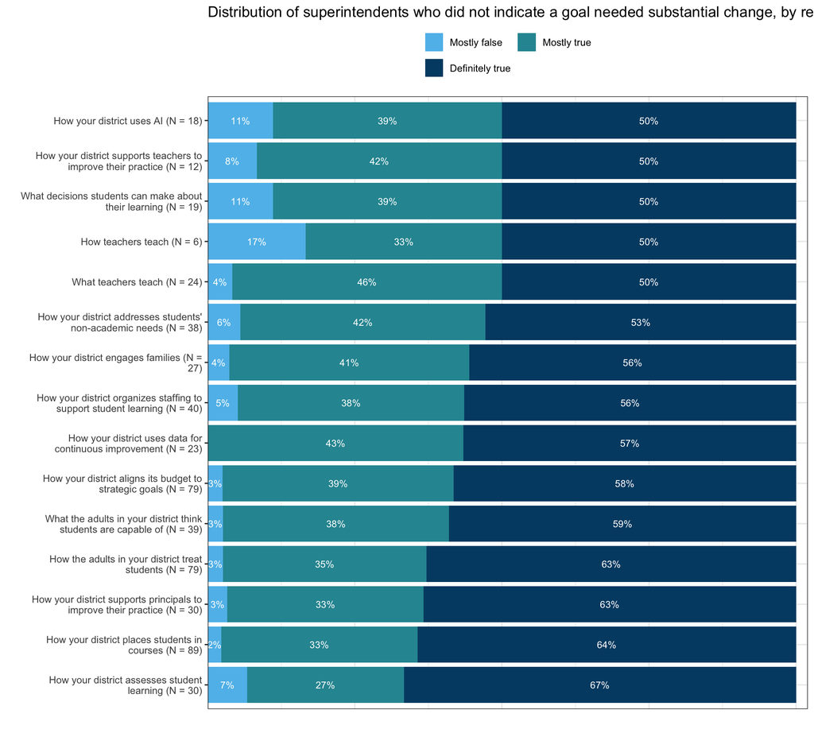

## By belief: I feel confident in my ability to lead transformational change in my current district.

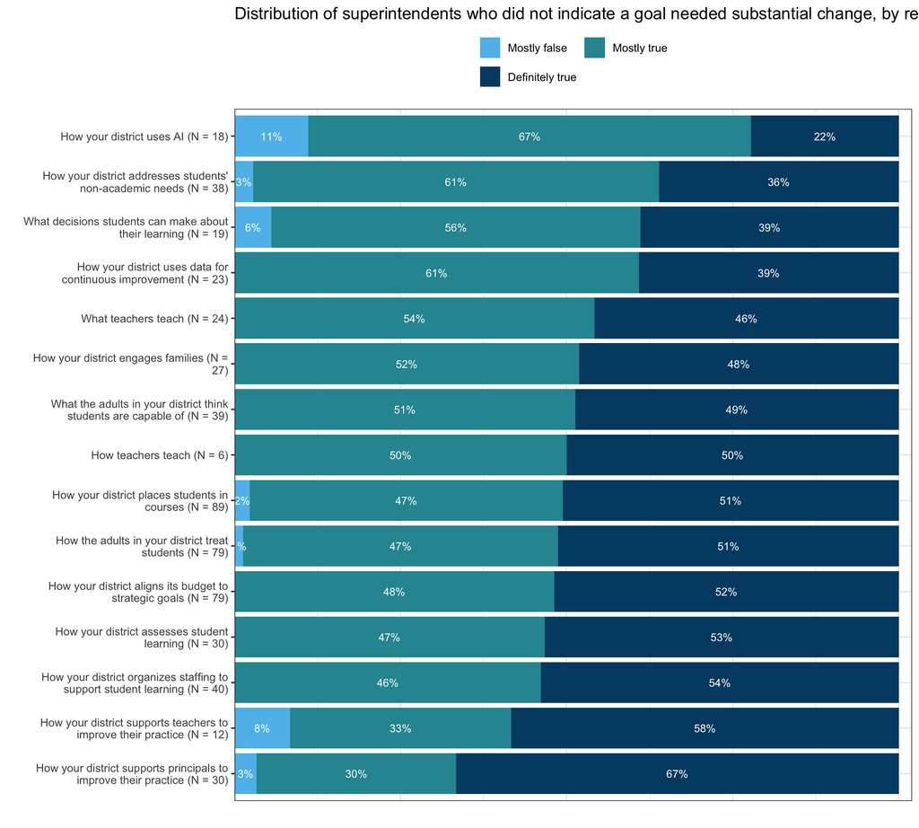

## By belief: My formal education prepared me to lead change efforts.

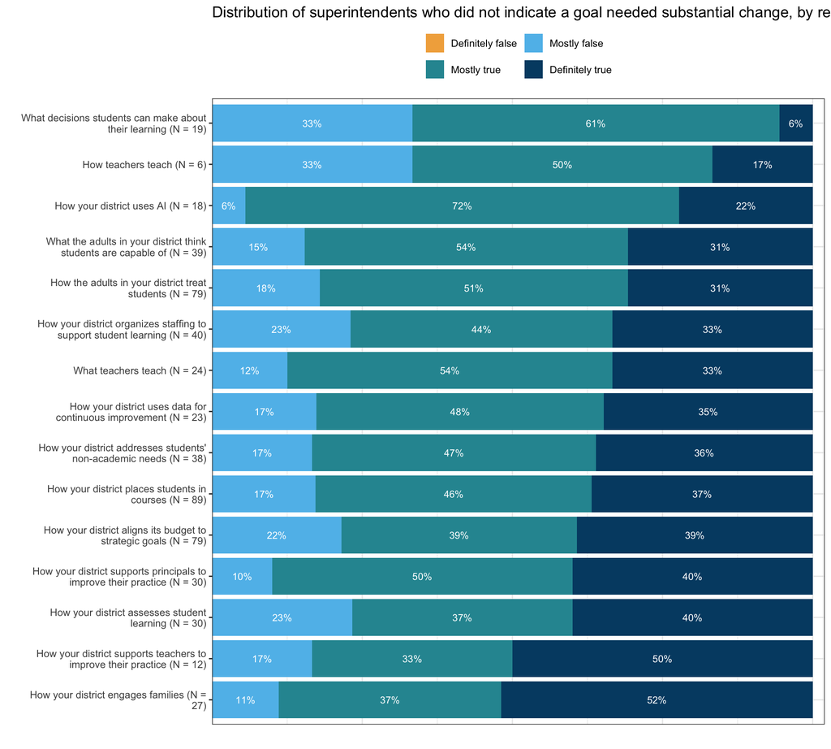

## By belief: In the past, I have been part of successful change efforts in a public school or district.

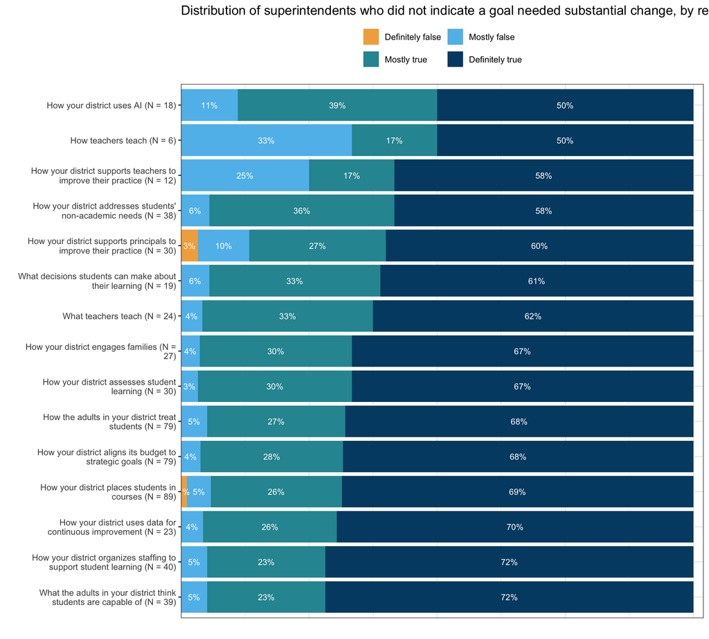

## By belief: In the past, I have been part of stalled or failed change efforts in a public school or district.

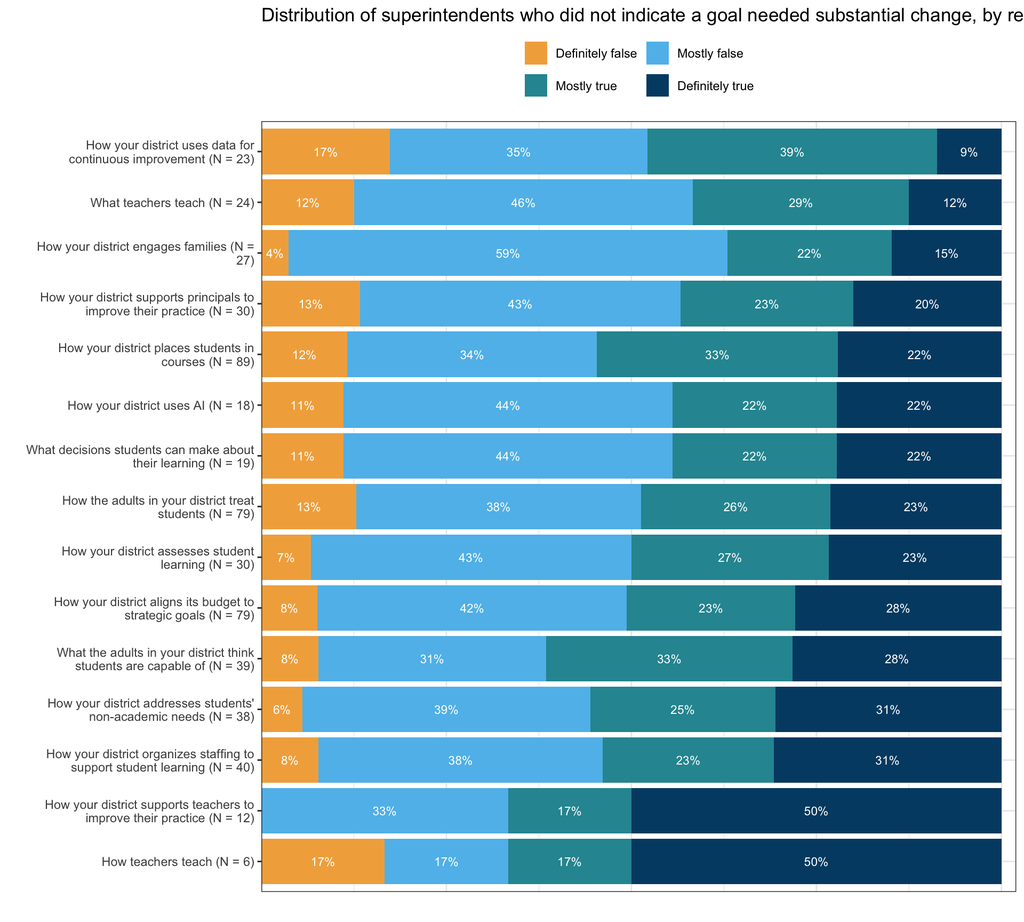

## By state

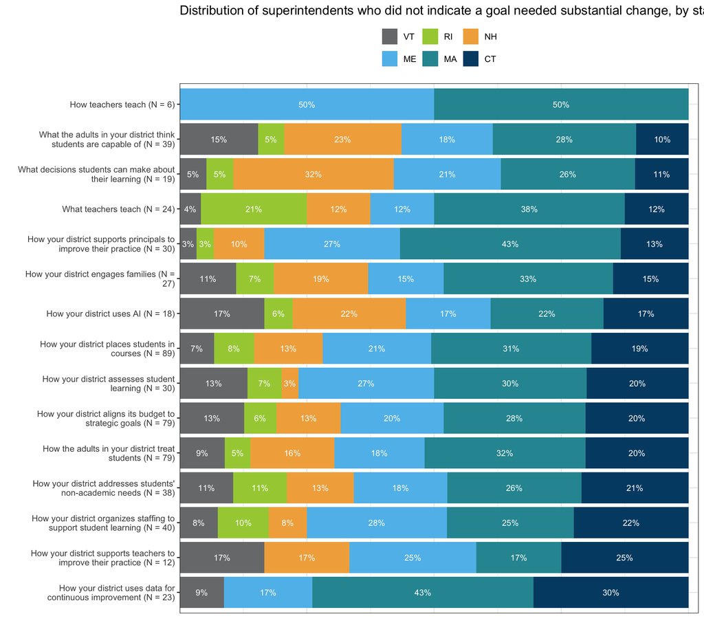

# Percentage-point difference

Because some groups are larger than others in the overall sample, raw percentages like in the prior section can be misleading. To account for baseline group size, I looked at percentage-point differences between each group’s share among those who said some goal did not need significant change and its share in the full sample.

## Co-occurence with other responses

Cells show the percentage-point difference between each group’s share among non-selectors and its share in the full sample. For example, a value of +3.4 means the group is 3.4 percentage points more common among non-selectors than in the overall sample. Positive values indicate overrepresentation; negative values indicate underrepresentation. Green cells mark values that were in the top percentile.

[e.g., diff_pp= (% of people who did NOT select “safe, welcoming” and who DID select “strengthen career prep”) − (% of the full sample who selected “strengthen career prep”)]

(This is the full table for reference but it can be hard to read due to size so below I’ve included a version highlighting where there were notable differences)

| row_label | How teachers teach (N = 6) | How the adults in your district treat students (N = 79) | How your district addresses students' non-academic needs (N = 38) | How your district aligns its budget to strategic goals (N = 79) | How your district assesses student learning (N = 30) | How your district engages families (N = 27) | How your district organizes staffing to support student learning (N = 40) | How your district places students in courses (N = 89) | How your district supports principals to improve their practice (N = 30) | How your district supports teachers to improve their practice (N = 12) | How your district uses AI (N = 18) | How your district uses data for continuous improvement (N = 23) | What decisions students can make about their learning (N = 19) | What teachers teach (N = 24) | What the adults in your district think students are capable of (N = 39) |
| --- | --- | --- | --- | --- | --- | --- | --- | --- | --- | --- | --- | --- | --- | --- | --- |
| Create safe, welcoming school community: Did not select | 0.4564166815822446 | -0.9195906432748563 | -0.8854847748925837 | -0.4947209653092005 | 0.6709462155006701 | -0.3223443223443201 | 0.371896024069937 | -2.659888691975251 | -0.1031940420981953 | 0.5884889235896668 | -0.3225460907651828 | 0.7990373044524685 | 0.1205157606533586 | -1.264948306255659 | -1.181368136813682 |
| Create safe, welcoming school community: Selected | -0.456416681582239 | 0.9195906432748591 | 0.8854847748925865 | 0.4947209653092033 | -0.6709462155006785 | 0.3223443223443256 | -0.3718960240699398 | 2.659888691975243 | 0.1031940420981869 | -0.5884889235896695 | 0.3225460907651745 | -0.7990373044524657 | -0.1205157606533613 | 1.264948306255653 | 1.181368136813676 |
| Develop students' durable skills: Did not select | 0.09620547700017745 | 1.068713450292397 | -0.8780123295348385 | -3.37254901960784 | -0.9211910202009232 | 0.5274725274725278 | -3.712503712503712 | -0.5207847526661091 | -0.5433228481555641 | -0.4824443848834126 | -0.7391185327128402 | 0.6835138387484951 | -0.2480518568787615 | 0.4383248368192871 | 1.110111011101106 |
| Develop students' durable skills: Selected | -0.09620547700018856 | -1.068713450292402 | 0.8780123295348385 | 3.372549019607851 | 0.9211910202009177 | -0.5274725274725278 | 3.712503712503712 | 0.5207847526661036 | 0.5433228481555585 | 0.482444384883407 | 0.7391185327128347 | -0.6835138387484951 | 0.2480518568787504 | -0.4383248368192927 | -1.110111011101111 |
| Eliminate disparities in outcomes: Did not select | -0.5190621084660785 | -2.336257309941519 | -2.716233887539693 | -1.728506787330314 | -0.9610851195009595 | -0.6080586080586092 | -2.423780684650251 | -3.362559462736686 | -0.1703323345476238 | -0.3426054327432926 | -2.282816981873148 | 0.599277978339352 | -1.814756745372431 | 1.055314688646436 | -1.102610261026105 |
| Eliminate disparities in outcomes: Selected | 0.519062108466084 | 2.336257309941525 | 2.716233887539699 | 1.728506787330319 | 0.9610851195009595 | 0.6080586080586148 | 2.423780684650256 | 3.362559462736681 | 0.1703323345476293 | 0.3426054327432926 | 2.282816981873148 | -0.5992779783393409 | 1.814756745372426 | -1.055314688646436 | 1.102610261026105 |
| Expand access to postsecondary education: Did not select | 0.4161446214426268 | -0.9459064327485334 | -1.523133445420022 | -2.007541478129715 | -0.2973923766002917 | 0.3626373626373636 | -1.508244986505858 | -4.802101793986879 | -0.7173850878392618 | 0.8460256604477245 | -1.19496780490127 | 0.785800240673884 | -0.5429059509044487 | 0.3620944304159379 | -1.687668766876682 |
| Expand access to postsecondary education: Selected | -0.4161446214426379 | 0.9459064327485389 | 1.523133445420011 | 2.00754147812971 | 0.2973923766002973 | -0.3626373626373636 | 1.508244986505852 | 4.802101793986879 | 0.7173850878392618 | -0.846025660447719 | 1.19496780490127 | -0.7858002406738895 | 0.5429059509044543 | -0.3620944304159324 | 1.687668766876688 |
| External partnerships: Definitely helps | -0.7407923135835159 | -0.5683971201212612 | -0.352455031599419 | -2.913856724774144 | -0.7623049219687872 | -1.154817216188359 | -0.04046062869592082 | -1.973118176777622 | -1.429445974900517 | -0.8694408694408684 | -0.2391367745698425 | -0.2133997243586927 | -0.766835793357934 | -0.7793357933579326 | -1.470588235294118 |
| External partnerships: Definitely hinders | 0.01670960105827476 |  | -0.322070977151191 | -0.2453965426353771 | -0.3271308523409363 | 0.07170921911648269 | -0.32057267351385 | -0.219872665047894 | -0.327517600244873 | 0.03146003146003145 | 0.04666083406240883 | -0.3364009543709895 | 0.04324261992619928 | 0.0619926199261993 | -0.3151260504201681 |

[output cut: 138 more lines]

This version zooms in on rows and goals where there were notable differences:

| row_label | How the adults in your district treat students (N = 79) | How your district addresses students' non-academic needs (N = 38) | How your district aligns its budget to strategic goals (N = 79) | How your district organizes staffing to support student learning (N = 40) | How your district places students in courses (N = 89) | What teachers teach (N = 24) |
| --- | --- | --- | --- | --- | --- | --- |
| Develop students' durable skills: Selected | -1.068713450292402 | 0.8780123295348385 | 3.372549019607851 | 3.712503712503712 | 0.5207847526661036 | -0.4383248368192927 |
| Expand access to postsecondary education: Selected | 0.9459064327485389 | 1.523133445420011 | 2.00754147812971 | 1.508244986505852 | 4.802101793986879 | -0.3620944304159324 |
| External partnerships: Helps more than hinders | 0.5178729316660413 | 1.276130286825472 | 3.399196553541894 | 0.08403361344537785 | 1.141425922031236 | 0.2833948339483361 |
| Family expectations: Helps more than hinders | 2.538296690213504 | 0.4055868922911543 | 1.366541413752131 | 0.9259513669460095 | 4.720032342834046 | 0.4475047443196378 |
| How your district addresses students' non-academic needs: Did not select | 2.500000000000002 | 0 | 2.500000000000002 | 0.2358490566037763 | 4.371373307543519 | 6.441223832528181 |
| How your district aligns its budget to strategic goals: Selected | 1.271186440677963 | 4.36507936507936 | 0 | 0 | 1.78571428571429 | -1.5625 |
| How your district assesses student learning: Did not select | -4.839189994044074 | -1.191723415400731 | 3.536048431480465 | 1.113794954374664 | 0.4347826086956552 | -1.234720335843931 |
| How your district assesses student learning: Selected | 4.839189994044069 | 1.191723415400736 | -3.536048431480465 | -1.113794954374669 | -0.4347826086956497 | 1.234720335843931 |
| How your district supports teachers to improve their practice: Did not select | 3.77574370709382 | 2.065217391304347 | 0.8152173913043459 | 1.383399209486164 | 3.811792733770098 | 1.383399209486164 |
| How your district uses AI: Did not select | 5.432575645025506 | 0.3144654088050314 | 2.733820247514707 | 0.9993969156543492 | 0.3144654088050314 | -0.02567064561673771 |

[output cut: 8 more lines]

## Demographic patterns

(This is the full table for reference but it can be hard to read due to size so below I’ve included a version highlighting where there were notable differences)

| row_label | How teachers teach (N = 6) | How the adults in your district treat students (N = 79) | How your district addresses students' non-academic needs (N = 38) | How your district aligns its budget to strategic goals (N = 79) | How your district assesses student learning (N = 30) | How your district engages families (N = 27) | How your district organizes staffing to support student learning (N = 40) | How your district places students in courses (N = 89) | How your district supports principals to improve their practice (N = 30) | How your district supports teachers to improve their practice (N = 12) | How your district uses AI (N = 18) | How your district uses data for continuous improvement (N = 23) | What decisions students can make about their learning (N = 19) | What teachers teach (N = 24) | What the adults in your district think students are capable of (N = 39) |
| --- | --- | --- | --- | --- | --- | --- | --- | --- | --- | --- | --- | --- | --- | --- | --- |
| change_group: 0 domains | -0.3957096740601879 | -4.092071611253196 | -1.162969414416723 | -2.336823896456925 | -2.526795552439145 | -1.582491582491584 | -1.451256704174993 | -4.14141414141414 | -1.48343832554359 | -0.8374571754853455 | -0.1822866031499115 | -2.49084519157512 | -0.5213424568263264 | -1.320901320901322 | -2.897048534632427 |
| change_group: 1-2 domains | -0.5970356485820394 | -7.023411371237459 | -1.659921102515499 | -7.435208352639544 | -1.016728438345188 | -1.784511784511783 | -3.596592701651069 | -5.945165945165948 | -2.499491973176188 | -0.5138941758660087 | -1.169064748201437 | 0.245766669124331 | -1.889866405995438 | -0.01110001110001257 | -2.448757482314528 |
| change_group: 3-5 domains | 0.8122461730709185 | 8.951406649616366 | 2.387417388185869 | 7.517066691378615 | 2.939997996594212 | 2.491582491582489 | 3.714901672100118 | 7.412217412217409 | 2.992277992277992 | 0.9802055576703494 | 0.7826171495236289 | 1.510236181769026 | 1.846421201259907 | 2.027602027602027 | 4.032028193102022 |
| change_group: 6-9 domains | 0.1804991495713143 | 2.164076332874287 | 0.4354731287463498 | 2.254965557717851 | 0.6035259941901239 | 0.875420875420875 | 1.332947733725943 | 2.674362674362674 | 0.9906523064417792 | 0.3711457936810048 | 0.5687342018277266 | 0.7348423406817559 | 0.5647876615618552 | -0.6956006956006955 | 1.313777823844937 |
| district_type: Charter | -0.4541793449078221 | -2.855263157894737 | -1.457126844759947 | -2.402714932126697 | -1.733579951401734 | -0.7435897435897441 | -1.049831484614093 | -3.884898796754034 | -1.780408051621887 | -0.5978115203990066 | -0.7165046001499655 | -0.5306859205776171 | -1.739873165937332 | -1.214922102053456 | -1.8001800180018 |
| district_type: Other | -0.2572937175586182 | -0.8362573099415204 | 0.1905473566224544 | -0.3800904977375563 | 0.06890798970006912 | -0.3369963369963369 | -0.5384744515179298 | 0.2518421789012216 | -1.411147443150029 | 0.1678067425681426 | -0.09878717909044404 | 0.3321299638989167 | -0.08658413872183121 | -0.3763876316165614 | -0.1725172517251725 |
| district_type: Regional | 0.2684804009307318 | 0.2909356725146195 | 0.8082695061959022 | 1.265460030165913 | 0.3880607841003886 | -0.4798534798534787 | 1.34554047597526 | 0.9778316699312867 | 0.7857666820007214 | 0.2249076480253576 | 0.1666289767790624 | -0.6702767749699162 | 0.2047597875178442 | 0.812330268235742 | 0.8625862586258637 |
| district_type: Traditional | 0.4429926615357127 | 3.400584795321637 | 0.4583099819415848 | 1.517345399698333 | 1.276611177601272 | 1.560439560439553 | 0.2427654601567686 | 2.655224947921531 | 2.405788812771203 | 0.2050971298055093 | 0.6486628024613528 | 0.8688327316486166 | 1.621697517141318 | 0.7789794654342708 | 1.110111011101111 |
| enrollment_cat: Average | 0.6917255470453298 | 1.871191692862362 | 1.829516539440201 | 1.314366910697184 | 2.259259259259261 | 1.54882154882155 | 2.454253864759698 | 3.363592928810322 | 1.458902722947664 | 0.3854206318995024 | 1.130176939529454 | 0.2998353363316886 | 0.8408982322025804 | 1.464274855579206 | -0.4605597964376595 |
| enrollment_cat: High | 0.6780280114602688 | 4.329365493199056 | 0.9694656488549613 | 4.374015383189694 | 1.444444444444443 | 0.6397306397306346 | 1.808812703754337 | 5.937251154642459 | 2.024496406518877 | 0.3140464408070032 | 0.6610927474236805 | -0.2064440020644431 | 1.532489249880553 | -0.01945880206749573 | 3.6412213740458 |

[output cut: 30 more lines]

This version zooms in on rows and goals where there were notable differences:

| row_label | How the adults in your district treat students (N = 79) | How your district aligns its budget to strategic goals (N = 79) | How your district places students in courses (N = 89) |
| --- | --- | --- | --- |
| change_group: 1-2 domains | -7.023411371237459 | -7.435208352639544 | -5.945165945165948 |
| change_group: 3-5 domains | 8.951406649616366 | 7.517066691378615 | 7.412217412217409 |
| enrollment_cat: Low | -6.200557186061406 | -5.688382293886884 | -9.30084408345278 |
| enrollment_change_cat: Average | 2.49760148472028 | 2.977084285434484 | 6.02890640792399 |
| enrollment_change_cat: High | -6.497224013463143 | -4.916106287131944 | -7.155852031534265 |
| serve_hs: Does not serve high school | -3.754385964912279 | -7.806938159879337 | -7.552156204334172 |
| serve_hs: Serves high school | 3.754385964912288 | 7.80693815987934 | 7.552156204334171 |

# TLDR

**Response patterns** Most subgroup differences in goals that were “deprioritized” (i.e., indicated as *not* needing substantial change) were modest, typically within ±1–2 percentage points. However, some cells fell in the top 1% of observed differences (marked in green). Surprisingly, these occurred within priority areas that had more respondents (N somewhere between ~25 and ~90), suggesting that they are not solely artifacts of small sample size.

While the magnitude of these differences was moderate (generally in the 3–6 percentage-point range), their recurrence across multiple priorities suggests a slight pattern rather than isolated variation.

There was no evidence of sharp divides along tenure or other structural categories. The outliers seem to reflect variation in goals and strategies rather than clear polarization across leader characteristics, as far as we can observe them from other survey questions.

**Demographics** When demographic and district characteristics are incorporated, clearer structural patterns emerge and there are more pronounced subgroup differences. Larger deviations are associated with district size, enrollment changes, whether or not the district has a high school, and overall breadth of perceived change needs (i.e., change group).

Low-enrollment and growing districts are more likely to view areas such as course placement, budget alignment, and how adults treat students as requiring substantial change. In contrast, districts that serve high school grades and those in one of the high change groups (3-5) are more likely to indicate that course placement, budget alignment, and how adults treat students do not need substantial change.

These patterns suggest that perceptions of need are shaped by district context, specifically related to size, growth, and grade spans which appear to influence how leaders assess the urgency of these goals.